# self-esteem

[output not shown]

Log  
Log - Log - April 14, 2025

* Encoding: UTF-8.  
* Load the data.  
GET FILE = 'self_esteem_gpa.sav'.  
>Error # 61 in column 12. Text: self_esteem_gpa.sav  
>The filename is not valid.  
>Execution of this command stops.  
* Descriptive statistics.  
DESCRIPTIVES VARIABLES = Self_Esteem GPA  
/STATISTICS = MEAN STDDEV MIN MAX.

Descriptives  
Descriptives - Descriptive Statistics - April 14, 2025

Descriptive StatisticsDescriptive Statistics, table, 1 levels of column headers and 1 levels of row headers, table with 6 columns and 5 rows

|  | N | Minimum | Maximum | Mean | Std. Deviation |
| --- | --- | --- | --- | --- | --- |
| Self_Esteem | 3 | 25.00 | 34.00 | 29.0000 | 4.58258 |
| GPA | 4 | 12.00 | 30.00 | 19.0000 | 7.74597 |
| Valid N (listwise) | 3 |  |  |  |  |

Log  
Log - Log - April 14, 2025

* Pearson correlation between Self-Esteem and GPA.  
CORRELATIONS  
/VARIABLES = Self_Esteem GPA  
/PRINT = TWOTAIL NOSIG  
/MISSING = PAIRWISE.

Correlations  
Correlations - Correlations - April 14, 2025

CorrelationsCorrelations, table, 1 levels of column headers and 2 levels of row headers, table with 4 columns and 8 rows

|  |  | Self_Esteem | GPA |
| --- | --- | --- | --- |
| Self_Esteem | Pearson Correlation | 1 | .929 |
|  | Sig. (2-tailed) |  | .242 |
|  | N | 3 | 3 |
| GPA | Pearson Correlation | .929 | 1 |
|  | Sig. (2-tailed) | .242 |  |
|  | N | 3 | 4 |

Log  
Log - Log - April 14, 2025

* Simple linear regression (predicting GPA from Self-Esteem).  
REGRESSION  
/DEPENDENT GPA  
/METHOD = ENTER Self_Esteem.

Regression  
Regression - Variables Entered/Removed - April 14, 2025

Variables Entered/Removed<sup>a</sup>Variables Entered/Removed, table, 1 levels of column headers and 1 levels of row headers, table with 4 columns and 5 rows

| Model | Variables Entered | Variables Removed | Method |
| --- | --- | --- | --- |
| 1 | Self_Esteem<sup>b</sup> | . | Enter |

a. Dependent Variable: GPA  
b. All requested variables entered.

Regression  
Regression - Model Summary - April 14, 2025

Model SummaryModel Summary, table, 1 levels of column headers and 1 levels of row headers, table with 5 columns and 4 rows

| Model | R | R Square | Adjusted R Square | Std. Error of the Estimate |
| --- | --- | --- | --- | --- |
| 1 | .929<sup>a</sup> | .862 | .724 | 1.60357 |

a. Predictors: (Constant), Self_Esteem

Regression  
Regression - ANOVA - April 14, 2025

ANOVA<sup>a</sup>ANOVA, table, 1 levels of column headers and 2 levels of row headers, table with 7 columns and 7 rows

| Model |  | Sum of Squares | df | Mean Square | F | Sig. |
| --- | --- | --- | --- | --- | --- | --- |
| 1 | Regression | 16.095 | 1 | 16.095 | 6.259 | .242<sup>b</sup> |
|  | Residual | 2.571 | 1 | 2.571 |  |  |
|  | Total | 18.667 | 2 |  |  |  |

a. Dependent Variable: GPA  
b. Predictors: (Constant), Self_Esteem

Regression  
Regression - Coefficients - April 14, 2025

Coefficients<sup>a</sup>Coefficients, table, 2 levels of column headers and 2 levels of row headers, table with 7 columns and 6 rows

[output not shown]

a. Dependent Variable: GPA

Log  
Log - Log - April 14, 2025

* Chart Builder.  
GGRAPH  
/GRAPHDATASET NAME="graphdataset" VARIABLES=Self_Esteem GPA MISSING=LISTWISE REPORTMISSING=NO  
/GRAPHSPEC SOURCE=INLINE  
/FITLINE TOTAL=YES.  
BEGIN GPL  
SOURCE: s=userSource(id("graphdataset"))  
DATA: Self_Esteem=col(source(s), name("Self_Esteem"))  
DATA: GPA=col(source(s), name("GPA"))  
GUIDE: axis(dim(1), label("Self_Esteem"))  
GUIDE: axis(dim(2), label("GPA"))  
GUIDE: text.title(label("Simple Scatter with Fit Line of GPA by Self_Esteem"))  
ELEMENT: point(position(Self_Esteem*GPA))  
END GPL.

GGraph  
GGraph - Graph - April 14, 2025

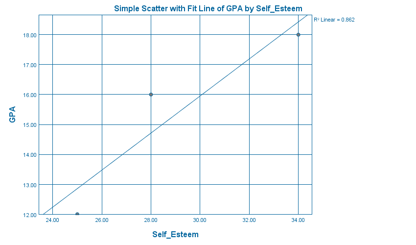

[output not shown]

[output not shown]

[output not shown]

[output not shown]

[output not shown]

[output not shown]

[output not shown]

[output not shown]

[output not shown]